# Week 11 Exercises

February 13, 2019

# Lab This Week

You have to individually:

- work with and manipulate strings with regular expressions
- compute and visualize percentiles and probabilities

## Preliminary

Let’s start with loading our packages.

```r
# Load tidyverse
library(tidyverse)
```

## Regular Expressions

See section 14.3 in *R for Data Science* for more practice working with regular expressions. We will only cover a few things here.

Let’s start by generating a table of names, along with a coolness ranking from 0 to 10.

```r
# Generate tibbles to work with
name_table <- tribble(
  ~Name, ~Coolness,
     "Mike", 10,
     "Eric", 10,
     "Erik", 9,
     "Ann", 8,
     "Matt", 1,
     "Dan", 0,
     "Erin", 10,
     "Sue", 6,
     "Alice", 7
)
```

Suppose we want to filter all names that start with an “E”. We can do this with a regular expression via the following.

```r
# Extract names that start with an E
letterE <- name_table %>%
  filter(str_detect(Name, "^E") == T)
letterE
```

```
## # A tibble: 3 x 2
##   Name  Coolness
##   <chr>    <dbl>
## 1 Eric        10
## 2 Erik         9
## 3 Erin        10
```

We can also compute the number or proportion of names that start with the letter E.

```r
# Compute number
numbE <- name_table %>%
  summarise(Prop = sum(str_detect(Name, "^E"))) %>%
  as.numeric()

# Compute proportion
propE <- name_table %>%
  summarise(Prop = mean(str_detect(Name, "^E"))) %>%
  as.numeric()
```

**Exercise**: Compute the proportion of words that end in a vowel.

## Percentiles

You will also need to compute percentiles and probabilities this week. Taken from Wikipedia: “A percentile is a measure used in statistics indicating the value below which a given percentage of observations in a group of observations falls. For example, the 20th percentile is the value below which 20% of the observations may be found.”

Suppose we wanted compute the percentiles of the “Coolness”. Note that we are interpreting “Coolness” as a continuous number here, so our interpretation is a little weird. In your lab this week, you will be computing percentiles on proportions, which are continuous.

Here is how we can do it in R.

```r
# Compute quantiles
quantile(name_table$Coolness)
```

```
##   0%  25%  50%  75% 100%
##    0    6    8   10   10
```

```r
# Designate the percentiles to compute
quantile(name_table$Coolness, c(.3,.6,.9))
```

```
##  30%  60%  90%
##  6.4  8.8 10.0
```

## Probabilities

Suppose we are interested in the question, “Is the name Erik actually really cool?”

His coolness paramter is a 9 out of 10, which is pretty high. This may suggest that the name is really cool. However, how cool is that name relative to everyone else?

To answer this question, we can can start with a histogram of the coolness paramter for all the names in the dataset. Then we add in a line corresponding to Erik’s score.

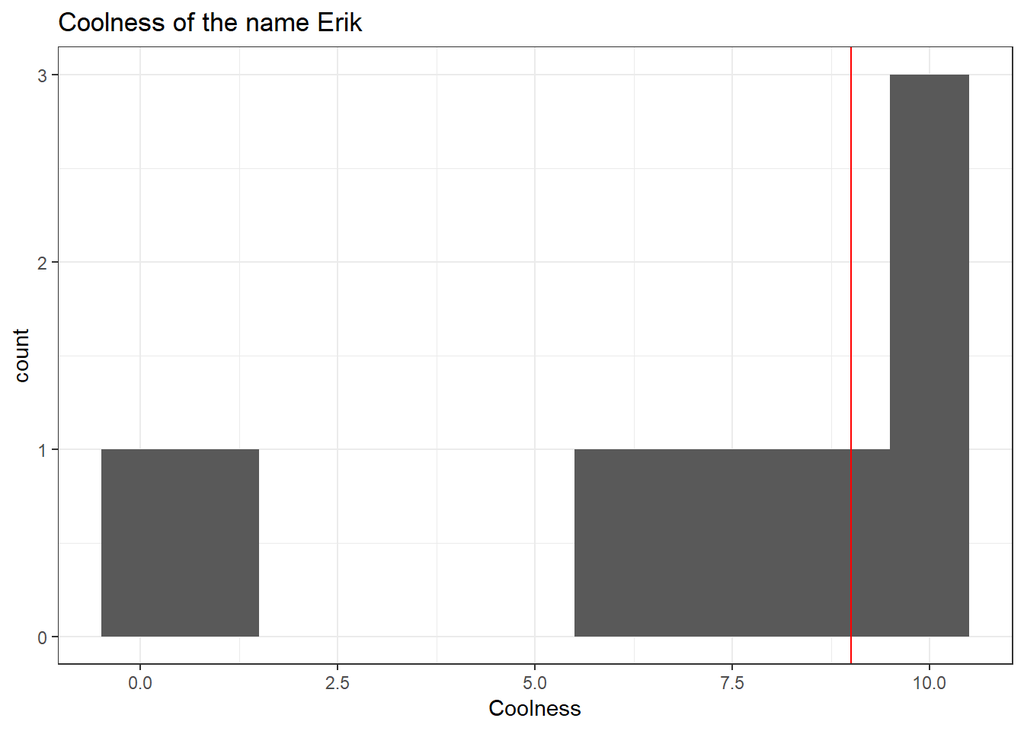

```r
# Compute histogram
# Bar plot is better for this categorical data
ggplot(data = name_table, aes(x = Coolness)) +
  geom_histogram(bins = 11) +
  theme_bw() +
  geom_vline(xintercept = 9, color = 'red') +
  ggtitle('Coolness of the name Erik')
```

There are alot of cooler names than “Erik”. Maybe a score of 9 doesn’t indicate a cool name? If everyone has cool names, can you actually have a cool name?

**Exercise**: Compute the probability of having a cooler name than Erik.